# Multiple and Logistic Regression

Amit Agni

11/03/2019

### Chapter 1 : Parallel slopes

- Models with one numerical and one categorical variable
- Same slope but different intercepts arising due to the categorical variables
- **Important to convert the categorical variable to factor**

```r
model <- lm(mpg ~ wt + factor(cyl), data = mtcars)
model
```

```
##
## Call:
## lm(formula = mpg ~ wt + factor(cyl), data = mtcars)
##
## Coefficients:
##  (Intercept)            wt  factor(cyl)6  factor(cyl)8
##       33.991        -3.206        -4.256        -6.071
```

```r
summary(model)
```

```
##
## Call:
## lm(formula = mpg ~ wt + factor(cyl), data = mtcars)
##
## Residuals:
##     Min      1Q  Median      3Q     Max
## -4.5890 -1.2357 -0.5159  1.3845  5.7915
##
## Coefficients:
##              Estimate Std. Error t value Pr(>|t|)
## (Intercept)   33.9908     1.8878  18.006  < 2e-16 ***
## wt            -3.2056     0.7539  -4.252 0.000213 ***
## factor(cyl)6  -4.2556     1.3861  -3.070 0.004718 **
## factor(cyl)8  -6.0709     1.6523  -3.674 0.000999 ***
## ---
## Signif. codes:  0 '***' 0.001 '**' 0.01 '*' 0.05 '.' 0.1 ' ' 1
##
## Residual standard error: 2.557 on 28 degrees of freedom
## Multiple R-squared:  0.8374, Adjusted R-squared:   0.82
## F-statistic: 48.08 on 3 and 28 DF,  p-value: 3.594e-11
```

**Visualising after `broom::augment()`**

> The `augment()` function from the broom package provides an easy way to add the fitted values to our data frame
- Model Intepretation
  - `mpg` would be 33.99 if the `wt` of the car was 0 and car had no `cyl`
  - `mpg` would change by -3.206 for a unit change in wt, after controlling for `cyl`
  - Cars with 6 `cyl` give -4.256 less `mpg` and cars with 8 `cyl` give -6.071 less `mpg` keeping `wt` constant

```r
# Augment the model
augmented_mod <- augment(model)
glimpse(augmented_mod)
```

```
## Observations: 32
## Variables: 11
## $ .rownames   <chr> "Mazda RX4", "Mazda RX4 Wag", "Datsun 710", "Horne...
## $ mpg         <dbl> 21.0, 21.0, 22.8, 21.4, 18.7, 18.1, 14.3, 24.4, 22...
## $ wt          <dbl> 2.620, 2.875, 2.320, 3.215, 3.440, 3.460, 3.570, 3...
## $ factor.cyl. <fct> 6, 6, 4, 6, 8, 6, 8, 4, 4, 6, 6, 8, 8, 8, 8, 8, 8,...
## $ .fitted     <dbl> 21.33650, 20.51907, 26.55377, 19.42916, 16.89262, ...
## $ .se.fit     <dbl> 1.0365535, 0.9835128, 0.7713714, 0.9692344, 0.8029...
## $ .resid      <dbl> -0.3365049, 0.4809265, -3.7537713, 1.9708350, 1.80...
## $ .hat        <dbl> 0.16434300, 0.14795437, 0.09101121, 0.14368963, 0....
## $ .sigma      <dbl> 2.602870, 2.601902, 2.491147, 2.571371, 2.577931, ...
## $ .cooksd     <dbl> 0.0010190268, 0.0018024669, 0.0593500660, 0.029105...
## $ .std.resid  <dbl> -0.14396643, 0.20376574, -1.53982877, 0.83294928, ...
```

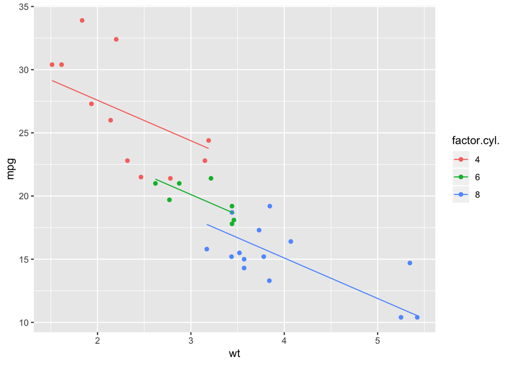

```r
# scatterplot, with color
data_space <- ggplot(augmented_mod, aes(x = wt, y = mpg, color = factor.cyl.)) +
  geom_point()

# single call to geom_line()
data_space +
  geom_line(aes(y = .fitted))
```

```r
model
```

```
##
## Call:
## lm(formula = mpg ~ wt + factor(cyl), data = mtcars)
##
## Coefficients:
##  (Intercept)            wt  factor(cyl)6  factor(cyl)8
##       33.991        -3.206        -4.256        -6.071
```

### Chapter 2 : Evaluating and extending parallel slopes model

**R-squared vs. adjusted R-squared**

Two common measures of how well a model fits to data are $R^2$ (the coefficient of determination) and the adjusted $R^2$. The former measures the percentage of the variability in the response variable that is explained by the model. To compute this, we define $R^2 = 1 - \frac{SSE}{SST}$

where $SSE$ are the sum of the squared residuals and $SST$ is the total sum of the squares

One issue with this measure is that the SSE can only decrease as new variable are added to the model, while the SST depends only on the response variable and therefore is not affected by changes to the model. This means that you can increase $R^2$ by adding any additional variable to your model—even random noise.

The adjusted $R^2$ includes a term that penalizes a model for each additional explanatory variable (where p is the number of explanatory variables).

$R^2_{adj} = 1 - \frac{SSE}{SST} \cdot \frac{n-1}{n-p-1}$

**Interaction**

> Interaction models are easy to visualize in the data space with ggplot2 because they have the same coefficients as if the models were fit independently to each group defined by the level of the categorical variable. In this case, new and used MarioKarts each get their own regression line. To see this, we can set an aesthetic (e.g. color) to the categorical variable, and then add a geom_smooth() layer to overlay the regression line for each color.

```r
lm(hwy~displ + factor(year), data = mpg)
```

```
##
## Call:
## lm(formula = hwy ~ displ + factor(year), data = mpg)
##
## Coefficients:
##      (Intercept)             displ  factor(year)2008
##           35.276            -3.611             1.402
```

```r
lm(hwy~displ + factor(year) + displ:factor(year), data = mpg)
```

```
##
## Call:
## lm(formula = hwy ~ displ + factor(year) + displ:factor(year),
##     data = mpg)
##
## Coefficients:
##            (Intercept)                   displ        factor(year)2008
##                35.7922                 -3.7684                  0.3445
## displ:factor(year)2008
##                 0.3052
```

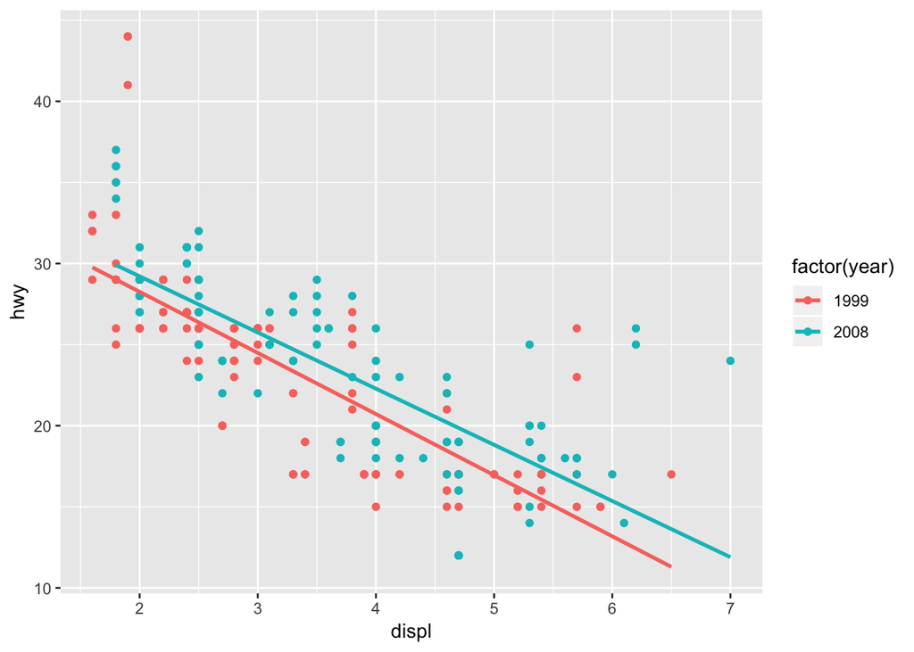

```r
ggplot(mpg) +
    aes(y=hwy,x=displ,color = factor(year)) +
    geom_point() +
    geom_smooth(method = "lm",se=FALSE)
```

**Simpsons Paradox**

- The relationship between variables changes if sub-groups are considered

### Chapter 3 : Multiple Linear Regression

- mpg drops by -1.9 for every increase in displ holding cyl constant
- similarly for cyl
- Cant compare both coeff as displ and cyl are in different units

```r
lm(hwy ~ displ + cyl, data = mpg)
```

```
##
## Call:
## lm(formula = hwy ~ displ + cyl, data = mpg)
##
## Coefficients:
## (Intercept)        displ          cyl
##      38.216       -1.960       -1.354
```

```r
summary(lm(hwy ~ displ + cyl, data = mpg))
```

```
##
## Call:
## lm(formula = hwy ~ displ + cyl, data = mpg)
##
## Residuals:
##     Min      1Q  Median      3Q     Max
## -7.5098 -2.1953 -0.2049  1.9023 14.9223
##
## Coefficients:
##             Estimate Std. Error t value Pr(>|t|)
## (Intercept)  38.2162     1.0481  36.461  < 2e-16 ***
## displ        -1.9599     0.5194  -3.773 0.000205 ***
## cyl          -1.3537     0.4164  -3.251 0.001323 **
## ---
## Signif. codes:  0 '***' 0.001 '**' 0.01 '*' 0.05 '.' 0.1 ' ' 1
##
## Residual standard error: 3.759 on 231 degrees of freedom
## Multiple R-squared:  0.6049, Adjusted R-squared:  0.6014
## F-statistic: 176.8 on 2 and 231 DF,  p-value: < 2.2e-16
```

**Adding third categorical variable**

- Parallel planes
- Cars manufactured in 2008 will have 1.336 higher mpg than cars manufactured in 1999, assuming displ and cyl is held constant
- Intepret the coeff of numerical variables as slopes and those of categorical variables as intercepts

```r
lm(formula = hwy ~ displ + cyl + factor(year), data = mpg)
```

```
##
## Call:
## lm(formula = hwy ~ displ + cyl + factor(year), data = mpg)
##
## Coefficients:
##      (Intercept)             displ               cyl  factor(year)2008
##           37.726            -2.091            -1.307             1.336
```

### Chapter 4 : Logistic Regression

- Generalised linear models for fitting models where the response variable is not normal
- One example is binary response
- Apply link function to appropiratly transfer the scale of the response variable to match the output of the linear model

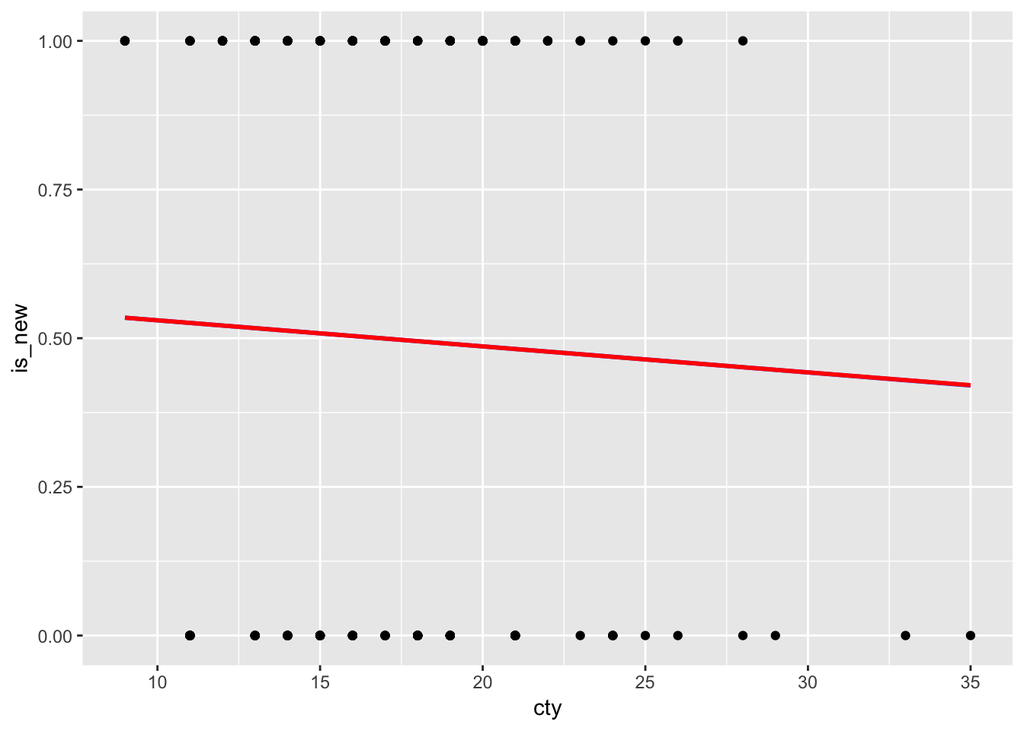

```r
mpg$is_new <- ifelse(mpg$year >2000, 1,0)

ggplot(mpg,aes(x=cty, y=is_new)) +
    geom_point() +
    geom_smooth(method = "lm", se= 0) +
    geom_smooth(method = "glm", se= 0,color = "red",
                method.args = list(family = "binomial"))
```

**Comparison of three scales**

> Thus, the exponentiated coefficent β1 tells us how the expected odds change for a one unit increase in the explanatory variable. It is tempting to interpret this as a change in the expected probability, but this is wrong and can lead to nonsensical predictions (e.g. expected probabilities greater than 1).

** Using a logistic model **

- The type argument in the predict (or the augment funtcion) take value as below
  - The default `link` is on the scale of the linear predictors. Thus for a default binomial model the default predictions are of log-odds (probabilities on logit scale). i.e The fitted values are on the log-odds scale and not very useful
  - the alternative `response` is on the scale of the response variable. `type = "response"` gives the predicted probabilities. Here the fitted values are retrieved on the familiar probability scale (ie between 0 and 1)
  - The `terms` option returns a matrix giving the fitted values of each term in the model formula on the linear predictor scale.

### Chapter 5 : Case Study

> Multiple regression can be an effective technique for understanding how a response variable changes as a result of changes to more than one explanatory variable. But it is not magic – understanding the relationships among the explanatory variables is also necessary, and will help us build a better model. This process is often called exploratory data analysis (EDA) and is covered in another DataCamp course.

> One quick technique for jump-starting EDA is to examine all of the pairwise scatterplots in your data. This can be achieved using the pairs() function. Look for variables in the nyc data set that are strongly correlated, as those relationships will help us check for multicollinearity later on.

> Which pairs of variables appear to be strongly correlated?

```r
nyc <- fread(here("nyc-data.csv"))
nyc$Case <- as.integer(nyc$Case)
nyc$Restaurant <- as.factor(nyc$Restaurant)
glimpse(nyc)
```

```
## Observations: 168
## Variables: 7
## $ Case       <int> 1, 2, 3, 4, 5, 6, 7, 8, 9, 10, 11, 12, 13, 14, 15, ...
## $ Restaurant <fct> Daniella Ristorante, Tello's Ristorante, Biricchino...
## $ Price      <int> 43, 32, 34, 41, 54, 52, 34, 34, 39, 44, 45, 47, 52,...
## $ Food       <int> 22, 20, 21, 20, 24, 22, 22, 20, 22, 21, 19, 21, 21,...
## $ Decor      <int> 18, 19, 13, 20, 19, 22, 16, 18, 19, 17, 17, 19, 19,...
## $ Service    <int> 20, 19, 18, 17, 21, 21, 21, 21, 22, 19, 20, 21, 20,...
## $ East       <int> 0, 0, 0, 0, 0, 0, 0, 1, 1, 1, 1, 1, 1, 1, 1, 1, 1, ...
```

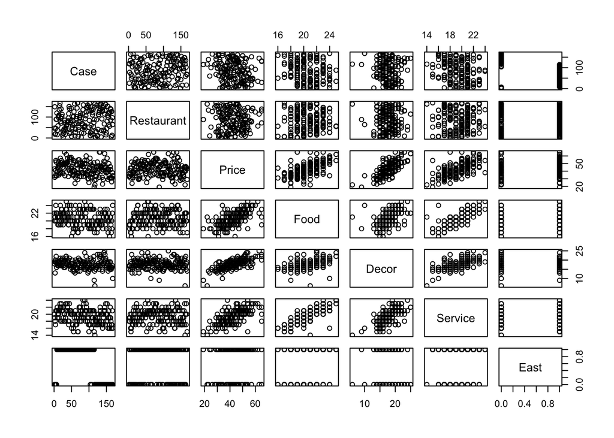

```r
pairs(nyc)
```

```r
nyc[which(is.na(nyc$Case)),]
```

```
## Empty data.table (0 rows) of 7 cols: Case,Restaurant,Price,Food,Decor,Service...
```

> SLR models Based on your knowledge of the restaurant industry, do you think that the quality of the food in a restaurant is an important determinant of the price of a meal at that restaurant? It would be hard to imagine that it wasn’t. We’ll start our modeling process by plotting and fitting a model for Price as a function of Food.

> On your own, interpret these coefficients and examine the fit of the model. What does the coefficient of Food mean in plain English? “Each additional rating point of food quality is associated with a…”

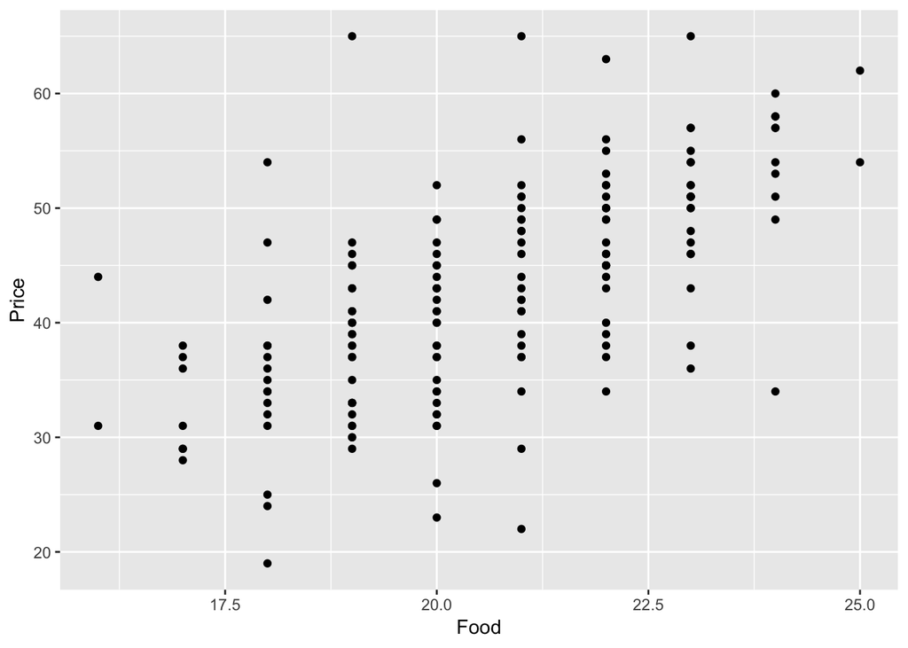

```r
# Price by Food plot
ggplot(data = nyc, aes(x = Food, y = Price)) +
  geom_point()
```

```r
# Price by Food model
lm(Price ~ Food, data = nyc)
```

```
##
## Call:
## lm(formula = Price ~ Food, data = nyc)
##
## Coefficients:
## (Intercept)         Food
##     -17.832        2.939
```

**Incorporating another variable**

- Do Italian restaurants located on the East Side of 5th Avenue tend to charge more ? If yes, how much more ?

> Let’s expand our model into a parallel slopes model by including the East variable in addition to Food.

> Use lm() to fit a parallel slopes model for Price as a function of Food and East. Interpret the coefficients and the fit of the model. Can you explain the meaning of the coefficient on East in simple terms? Did the coefficient on Food change from the previous model? If so, why? Did it change by a lot or just a little?

> Each additional rating point of food quality is associated with a $2.88 increase in the expected price of meal, after controlling for location.

> The premium for an Italian restaurant in NYC associated with being on the east side of 5th Avenue is $1.46, after controlling for the quality of the food.

```r
lm(Price ~ Food + factor(East), data = nyc)
```

```
##
## Call:
## lm(formula = Price ~ Food + factor(East), data = nyc)
##
## Coefficients:
##   (Intercept)           Food  factor(East)1
##       -17.430          2.875          1.459
```

> Are people willing to pay more for better restaurant Service? More interestingly, are they willing to pay more for better service, after controlling for the quality of the food?

```r
lm(Price ~ Food + Service, data = nyc)
```

```
##
## Call:
## lm(formula = Price ~ Food + Service, data = nyc)
##
## Coefficients:
## (Intercept)         Food      Service
##     -21.159        1.495        1.704
```

```r
# draw 3D scatterplot
#p <- plot_ly(data = nyc, z = ~Price, x = ~Food, y = ~Service, opacity = 0.6) %>%
#  add_markers()

# draw a plane
#p %>%
#  add_surface(x = ~x, y = ~y, z = ~plane, showscale = FALSE)
```

**Higher dimensions**

- **One variable could be a collinear with a linear combination of multiple variables**
- Results in unstable coefficient estimates, though it doenst affect R2
- Interpretation of location coefficient
  - The premium for being on the East side of 5th Avenue is just less than a dollar, after controlling for the quality of food and service. press
  - The impact of location is relatively small, since one additional rating point of either food or service would result in a higher expected price than moving a restaurant from the West side to the East side. press

```r
lm(Price ~ Food + Service + East, data = nyc)
```

```
##
## Call:
## lm(formula = Price ~ Food + Service + East, data = nyc)
##
## Coefficients:
## (Intercept)         Food      Service         East
##    -20.8155       1.4863       1.6647       0.9649
```

```r
# draw 3D scatterplot
p <- plot_ly(data = nyc, z = ~Price, x = ~Food, y = ~Service, opacity = 0.6) %>%
  add_markers(color = ~factor(East))

# draw two planes
p %>%
  add_surface(x = ~x, y = ~y, z = ~plane0, showscale = FALSE) %>%
  add_surface(x = ~x, y = ~y, z = ~plane1, showscale = FALSE)
```

**Adding All variables**

- Notice the dramatic change in the value of the Service coefficient.
  - Since the quality of food, decor, and service were all strongly correlated, multicollinearity is the likely explanation
  - Once we control for the quality of food, decor, and location, the additional information conveyed by service is negligible.

```r
lm(Price ~ Food+ Service+ Decor+East,data= nyc)
```

```
##
## Call:
## lm(formula = Price ~ Food + Service + Decor + East, data = nyc)
##
## Coefficients:
## (Intercept)         Food      Service        Decor         East
##  -24.023800     1.538120    -0.002727     1.910087     2.068050
```

# Summary

### Chapter 1 : Parallel Slopes

- Same slope but different intercepts arising due to the categorical variables
- Important to convert the categorical variable to factor
- The `broom::augment()` function - an easy way to add the fitted values to our data frame

### Chapter 2 : Evaluating and extending parallel slopes model

- The adjusted $R^2$ includes a term that penalizes a model for each additional explanatory variable (where p is the number of explanatory variables). $R^2_{adj} = 1 - \frac{SSE}{SST} \cdot \frac{n-1}{n-p-1}$
- Simpsons Paradox : The relationship between variables **changes** if sub-groups in the variables are considered

### Chapter 3 : Multiple Linear Regression

- Intepret the coeff of numerical variables as slopes and those of categorical variables as intercepts

### Chapter 5 : Case Study

- One variable could be a collinear with a linear combination of multiple variables